# Tratamendo de dados do dataset e-SUS Notifica

Juan Carlos Carbajal Ipenza

# 1 Introdução

Documento feito para tratar os dados do dataset e-SUS Notifica. As fontes principais para ter conhecimento dos dados são:

- [FICHA DE INVESTIGAÇÃO DE SG SUSPEITO DE DOENÇA PELO CORONAVÍRUS 2019 – COVID-19 (B34.2)](https://opendatasus.saude.gov.br/dataset/140cf8b0-cade-43d8-b358-30d472c50fad/resource/a6a0be53-671c-4291-b3dc-8b1259671278/download/ficha-covid-19-05_10_20_rev.pdf)
- [Instrutivo de preenchimento da ficha de notificação de caso de Síndrome Gripal suspeito de doença pelo Coronavírus 2019 – COVID-19 (B34.2)](https://opendatasus.saude.gov.br/dataset/140cf8b0-cade-43d8-b358-30d472c50fad/resource/b10b9483-6eda-4c99-b5bd-6a6d7b8bb34c/download/instrutivo-e-sus-notifica-29-09-2020_revisado.pdf)
- [Dicionário de dados – e-SUS Notifica (via OpenDatasus)](https://opendatasus.saude.gov.br/dataset/140cf8b0-cade-43d8-b358-30d472c50fad/resource/0c0d4c0b-4000-4bc8-86f3-5ff286b468a2/download/dicionario-de-dados_e-sus-notifica-opendatasus-1.pdf)

## 1.1 Livrarias

```r
library(plyr)
library(readr)
library(stringr)
```

# 2 Download dos dados

```r
list_dados = c("ac", "al", "ap", "am", "ba-1", "ba-2", "ba-3", "ce-1", "ce-2",
               "df", "es", "go-1", "go-2", "ma", "mt", "ms", "mg-1", "mg-2",
               "mg-3", "mg-4", "pa", "pb", "pr-1", "pr-2", "pe-1", "pe-2",
               "pi", "rj-1", "rj-2", "rj-3", "rn", "rs-1", "rs-2", "rs-3",
               "rs-4", "ro", "rr", "sc-1", "sc-2", "sc-3", "sc-4", "to",
               "se", "sp-1", "sp-2", "sp-3", "sp-4", "sp-5", "sp-6", "sp-7",
               "sp-8", "sp-9", "sp-10")

for (state in list_dados) {
   filename = paste("dados-", state, ".csv", sep = "")
   fullFilename = paste("dados/", filename, sep = "")
   if (!file.exists(fullFilename)) {
      download.file(
         paste("https://s3-sa-east-1.amazonaws.com/ckan.saude.gov.br/",
               filename, sep = ""),
         destfile = fullFilename)
   }
}
```

# 3 Importar dados, strings vazios como NA, strings como fatores

## 3.1 Importando dados

**Atenção:** Antes de importar os dados abrir os arquivos do estado de RJ e procurar pela palavra **diabettes** daí substituir a coluna de síntomas que tem dados com ponto vírgula pela vírgula. Tem que ficar assim: *“Doenças respiratórias crônicas descompensadas,rinite alergica, pré diabettes, obsidade”*

Para importar um csv

```r
importCSV <- function(file) {
   print(paste("Importing ", file, " ...", sep = ""))
   csv = read.csv(file, sep = ";", na.strings = "", stringsAsFactors = T,
                  colClasses = c(
                     "character", "character", "character", "NULL",
                     # id, dataNotificacao, dataInicioSintomas, dataNascimento
                     "character", "factor", "NULL", "character",
                     # sintomas, profissionalSaude, cbo, condicoes
                     "factor", "character", "factor", "factor",
                     # estadoTeste, dataTeste, tipoTeste, resultadoTeste
                     "NULL", "factor", "NULL", "factor",
                     # paisOrigem, sexo, estado, estadoIBGE
                     "NULL", "factor", "NULL", "NULL",
                     # municipio, municipioIBGE, origem, estadoNotificacao
                     "factor", "NULL", "factor", "NULL",
                     # estadoNotificacaoIBGE, municipioNotificacao,
                     # municipioNotificacaoIBGE, excluido
                     "NULL", "character", "character", "factor",
                     # validado, idade, dataEncerramento, evolucaoCaso
                     "factor")) # classificacaoFinal
   return(csv)
}
```

Processando todos os cSV’s

```r
myfiles = list.files(path="dados", pattern="*.csv", full.names=TRUE)
myfiles
```

```
 [1] "dados/dados-ac.csv"    "dados/dados-al.csv"    "dados/dados-am.csv"
 [4] "dados/dados-ap.csv"    "dados/dados-ba-1.csv"  "dados/dados-ba-2.csv"
 [7] "dados/dados-ba-3.csv"  "dados/dados-ce-1.csv"  "dados/dados-ce-2.csv"
[10] "dados/dados-df.csv"    "dados/dados-es.csv"    "dados/dados-go-1.csv"
[13] "dados/dados-go-2.csv"  "dados/dados-ma.csv"    "dados/dados-mg-1.csv"
[16] "dados/dados-mg-2.csv"  "dados/dados-mg-3.csv"  "dados/dados-mg-4.csv"
[19] "dados/dados-ms.csv"    "dados/dados-mt.csv"    "dados/dados-pa.csv"
[22] "dados/dados-pb.csv"    "dados/dados-pe-1.csv"  "dados/dados-pe-2.csv"
[25] "dados/dados-pi.csv"    "dados/dados-pr-1.csv"  "dados/dados-pr-2.csv"
[28] "dados/dados-rj-1.csv"  "dados/dados-rj-2.csv"  "dados/dados-rj-3.csv"
[31] "dados/dados-rn.csv"    "dados/dados-ro.csv"    "dados/dados-rr.csv"
[34] "dados/dados-rs-1.csv"  "dados/dados-rs-2.csv"  "dados/dados-rs-3.csv"
[37] "dados/dados-rs-4.csv"  "dados/dados-sc-1.csv"  "dados/dados-sc-2.csv"
[40] "dados/dados-sc-3.csv"  "dados/dados-sc-4.csv"  "dados/dados-se.csv"
[43] "dados/dados-sp-1.csv"  "dados/dados-sp-10.csv" "dados/dados-sp-2.csv"
[46] "dados/dados-sp-3.csv"  "dados/dados-sp-4.csv"  "dados/dados-sp-5.csv"
[49] "dados/dados-sp-6.csv"  "dados/dados-sp-7.csv"  "dados/dados-sp-8.csv"
[52] "dados/dados-sp-9.csv"  "dados/dados-to.csv"
```

```r
dados = ldply(myfiles, importCSV)
```

```r
colnames(dados)
```

```
 [1] "ÿid"                      "dataNotificacao"          "dataInicioSintomas"
 [4] "sintomas"                 "profissionalSaude"        "condicoes"
 [7] "estadoTeste"              "dataTeste"                "tipoTeste"
[10] "resultadoTeste"           "sexo"                     "estadoIBGE"
[13] "municipioIBGE"            "estadoNotificacaoIBGE"    "municipioNotificacaoIBGE"
[16] "idade"                    "dataEncerramento"         "evolucaoCaso"
[19] "classificacaoFinal"       "estadoNotificacao"        "municipioNotificacao"
[22] "validado"
```

```r
dim(dados)
```

```
[1] 42910656       22
```

```r
head(dados)
```

|  | ÿid | dataNotificacao | dataInicioSintomas | sintomas | profissionalSaude | condicoes | estadoTeste | dataTeste | tipoTeste | resultadoTeste | sexo | estadoIBGE | municipioIBGE | estadoNotificacaoIBGE | municipioNotificacaoIBGE | idade | dataEncerramento | evolucaoCaso | classificacaoFinal | estadoNotificacao | municipioNotificacao | validado |
| --- | --- | --- | --- | --- | --- | --- | --- | --- | --- | --- | --- | --- | --- | --- | --- | --- | --- | --- | --- | --- | --- | --- |
| 1 | 3ODKsTM6Iq | 2020-04-20T03:00:00.000Z | 2020-04-15T03:00:00.000Z | Dor de Garganta, Tosse | Não | null | Coletado | 2020-04-20T03:00:00.000Z | null | null | Masculino | 12 | 1200450 | 12 | 1200401 | 51 | NA | NA | NA | NA | NA | NA |
| 2 | IqnffBRttV | 2020-04-21T17:00:15.391Z | 2020-04-13T05:00:00.000Z | Outros | Não | null | Coletado | 2020-04-21T05:00:00.000Z | null | null | Feminino | 12 | 1200450 | 12 | 1200401 | 47 | NA | NA | NA | NA | NA | NA |
| 3 | pi0EZEFqCF | 2020-04-22T09:12:45.446Z | 2020-04-12T04:00:00.000Z | Febre, Tosse, Outros | Não | Doenças cardíacas crônicas, Diabetes | Coletado | 2020-04-22T04:00:00.000Z | null | null | Feminino | 12 | 1200401 | 12 | 1200401 | 57 | NA | NA | NA | NA | NA | NA |
| 4 | t6jUD1xWg2 | 2020-03-18T05:00:00.000Z | 2020-03-17T05:00:00.000Z | Febre, Tosse, Outros | Não | null | Concluído | 2020-03-18T05:00:00.000Z | RT-PCR | Positivo | Feminino | 12 | 1200401 | 12 | 1200401 | 27 | 2020-04-10T05:00:00.000Z | Cura | Confirmado Laboratorial | NA | NA | NA |
| 5 | EYngeYglcP | 2020-03-18T05:00:00.000Z | 2020-03-18T05:00:00.000Z | Tosse, Febre, Dor de Garganta, Dispneia, Outros | Sim | null | Concluído | 2020-03-19T05:00:00.000Z | RT-PCR | Positivo | Masculino | 12 | 1200401 | 12 | 1200401 | 30 | 2020-04-10T05:00:00.000Z | Cura | Confirmado Laboratorial | NA | NA | NA |
| 6 | ueBt6981Cg | 2020-03-24T05:00:00.000Z | 2020-03-17T05:00:00.000Z | Febre | Não | null | Concluído | 2020-03-24T05:00:00.000Z | RT-PCR | Positivo | Masculino | 12 | 1200401 | 12 | 1200401 | 34 | 2020-04-13T05:00:00.000Z | Cura | Confirmado Laboratorial | NA | NA | NA |

## 3.2 Corrigindo colunas

```r
colnames(dados)[1] = "id"
dados$estadoNotificacao = NULL
dados$municipioNotificacao = NULL
dados$validado = NULL

colnames(dados)
```

```
 [1] "id"                       "dataNotificacao"          "dataInicioSintomas"
 [4] "sintomas"                 "profissionalSaude"        "condicoes"
 [7] "estadoTeste"              "dataTeste"                "tipoTeste"
[10] "resultadoTeste"           "sexo"                     "estadoIBGE"
[13] "municipioIBGE"            "estadoNotificacaoIBGE"    "municipioNotificacaoIBGE"
[16] "idade"                    "dataEncerramento"         "evolucaoCaso"
[19] "classificacaoFinal"
```

# 4 Explorando dados categóricos

## 4.1 Profissional de saúde

```r
summary(dados$profissionalSaude)
```

```
      Não      null       Sim undefined    Médico       Nao      NA's
 40168798    294147   2262977         2         1         2    184729
```

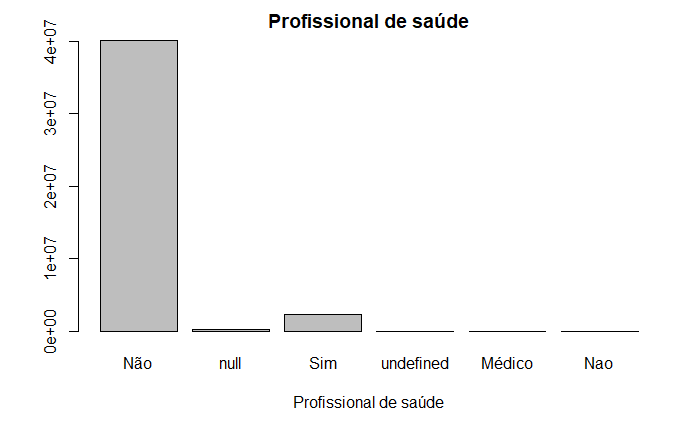

```r
counts = table(dados$profissionalSaude)
barplot(counts, main = "Profissional de saúde", xlab = "Profissional de saúde")
```

## 4.2 Sexo

```r
summary(dados$sexo)
```

```
  Feminino Indefinido  Masculino       null  undefined          M
  22084743     139899   20683175       2835          2          2
```

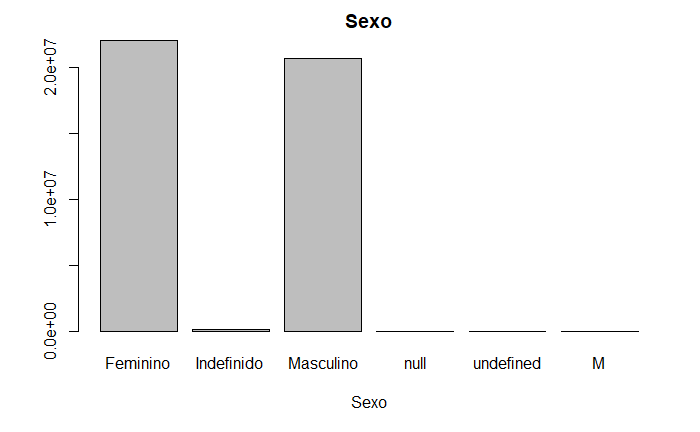

```r
counts = table(dados$sexo)
barplot(counts, main = "Sexo", xlab = "Sexo")
```

## 4.3 Estado do teste

```r
summary(dados$estadoTeste)
```

```
            Coletado            Concluído Exame Não Solicitado                 null
             3963201             31756805              2412794              1806010
          Solicitado            undefined                 NA's
             2971316                    2                  528
```

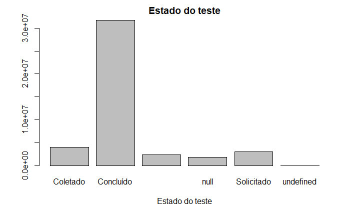

```r
counts = table(dados$estadoTeste)
barplot(counts, main = "Estado do teste", xlab = "Estado do teste")
```

## 4.4 Tipo de teste

```r
summary(dados$tipoTeste)
```

```
                         Enzimaimunoensaio \023 ELISA
                                                11763
                        Enzimaimunoensaio - ELISA IgM
                                                48297
 Imunoensaio por Eletroquimioluminescência \023 ECLIA
                                                17152
Imunoensaio por Eletroquimioluminescência - ECLIA IgG
                                                63989
                                                 null
                                              7321897
                           Quimioluminescência - CLIA
                                                27260
                                               RT-PCR
                                             15652759
                             TESTE RÁPIDO - ANTICORPO
                                             15703522
                              TESTE RÁPIDO - ANTÍGENO
                                              4063395
                                         Teste rápido
                                                   80
                                            undefined
                                                    2
                                                 NA's
                                                  540
```

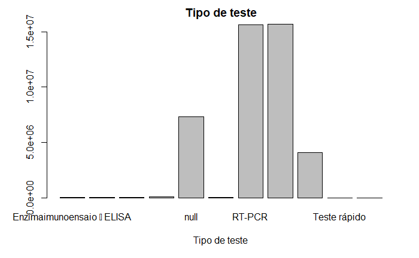

```r
counts = table(dados$tipoTeste)
barplot(counts, main = "Tipo de teste", xlab = "Tipo de teste")
```

## 4.5 Resultado do teste

```r
summary(dados$resultadoTeste)
```

```
Inconclusivo ou Indeterminado                      Negativo                          null
                        58470                      19889219                      11986714
                     Positivo                     undefined                          NA's
                     10976219                             2                            32
```

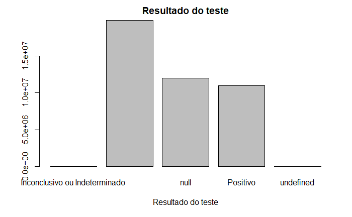

```r
counts = table(dados$resultadoTeste)
barplot(counts, main = "Resultado do teste", xlab = "Resultado do teste")
```

## 4.6 Evolução do caso

```r
summary(dados$evolucaoCaso)
```

```
               Cancelado                     Cura Em tratamento domiciliar
                 2112396                 12090024                  1155882
                Ignorado                Internado         Internado em UTI
                 2115777                    22620                     4639
                   Óbito                     NA's
                   71169                 25338149
```

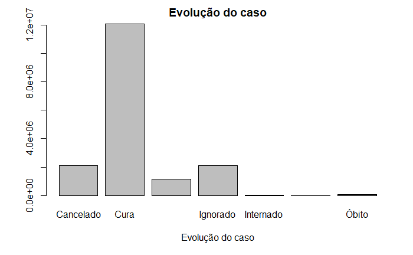

```r
counts = table(dados$evolucaoCaso)
barplot(counts, main = "Evolução do caso", xlab = "Evolução do caso")
```

## 4.7 Classificação final

```r
summary(dados$classificacaoFinal)
```

```
   Length     Class      Mode
 42910656 character character
```

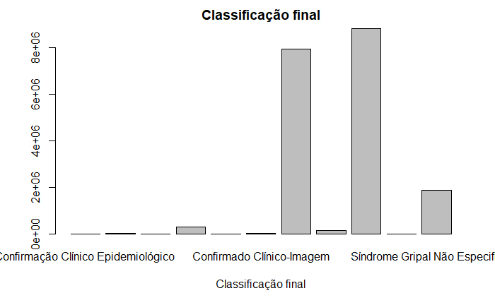

```r
counts = table(dados$classificacaoFinal)
barplot(counts, main = "Classificação final", xlab = "Classificação final")
```

## 4.8 Estado de residência

```r
summary(dados$estadoIBGE)
```

```
       12        27        13      null        16        29        23        53        32
   217398    522015    895946       257    175690   2595572   1488706    544786    511815
       52        21        31        50        51        15        25        26        22
  1607311    791804   4148110    835233    559992    880382    972974   1353020    591774
       11        14        17        24        28        33        35        41        42
   584247    240192    338515    913972    359794   2829491  10934165    125303   4001682
       43 undefined
  3889102      1408
```

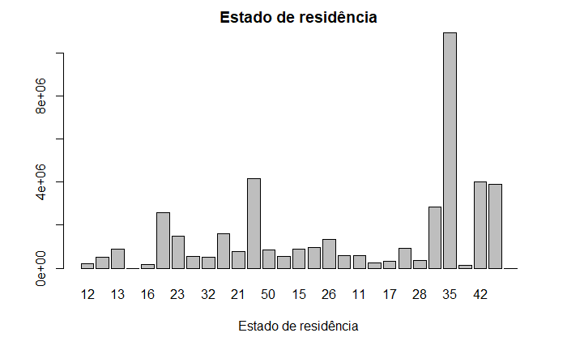

```r
counts = table(dados$estadoIBGE)
barplot(counts, main = "Estado de residência", xlab = "Estado de residência")
```

## 4.9 Municipio de residência

```r
summary(dados$municipioIBGE)
```

```
 3550308  4205407  3304557  3106200  2927408  5300108  1302603  5208707  4314902  2304400
 2907417  1852357  1034755   689967   647340   543937   530271   518872   484891   416416
 2611606  3548708  5002704  3509502  3170206  2408102  3549805  2507507  4209102  5201405
  405509   351950   350690   340563   336649   301643   284831   256292   247312   236284
 3304904  1100205  3549904  2704302  1400100  4305108  3552205  3547809  3543402  3303302
  230373   223072   215200   197046   196844   190548   190388   185069   170639   169198
 2211001  3518800  3525904  1501402  2111300  2800308  3538709  3118601  4304606  4216602
  166654   163812   162258   160797   157740   152827   152100   148160   134443   133937
 3534401  3530607  3529401  4202404  3300456  3506003  4314407  4204202  3548500  4314100
  127326   127146   123418   123053   120997   118731   111395   108354   107589   105988
 3505708  1200401  3513801  3552809  3106705  2933307  1600303  4208203  2504009  4316907
  103972   102730   100130    95895    94382    92450    91992    91726    91537    90894
 5003702  2910800  3502804  4315602  3503208  4313409  2403251  3143302  3507506  2700300
   89277    88438    88315    88179    86294    86010    85330    84158    83491    82890
 3170107  2914802  3516200  4309209  3131307  2905701  3554102  3541406  2408003  2607901
   82057    80418    79255    78796    78544    76418    73811    73699    72757    72740
 3510500  4318705  2604106  4204608  3306305  3301009  3205002  1506807  2307304  3302700
   72485    71828    71326    70522    70376    70097    69192    68901    67919    67018
 4211900  3524402  3205309  3205200  3505500  3529005  1702109  3526902  3543907  (Other)
   66969    66531    66302    66260    65889    65447    65272    64358    64153 21620178
```

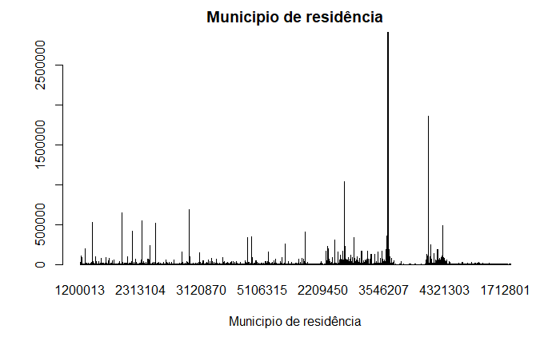

```r
counts = table(dados$municipioIBGE)
barplot(counts, main = "Municipio de residência",
        xlab = "Municipio de residência")
```

## 4.10 Estado da notificação

```r
summary(dados$estadoNotificacaoIBGE)
```

```
     11      12      13      14      15      16      17      21      22      23      24
 581725  211196  840131  233765  865175  166219  336989  758110  583225 1405010  902491
     25      26      27      28      29      31      32      33      35      41      42
 959003 1338107  510525  356537 2532947 3817452  472077 2789846 9113102 1346398 4029429
     43      50      51      52      53    null    NA's
3871653  838613  545186 1539564  527881   35609 1402691
```

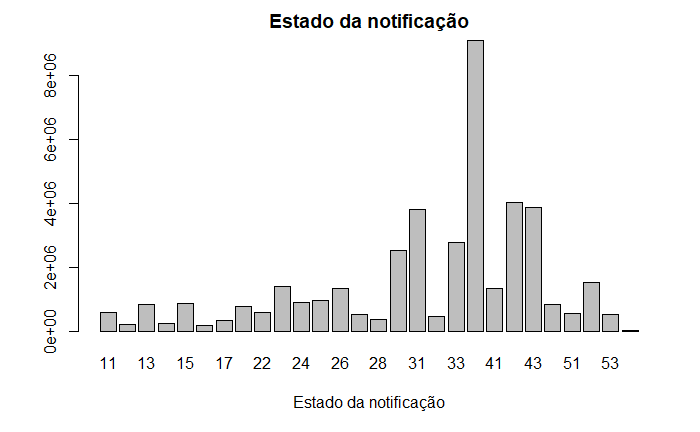

```r
counts = table(dados$estadoNotificacaoIBGE)
barplot(counts, main = "Estado da notificação", xlab = "Estado da notificação")
```

## 4.11 Municipio da notificação

```r
summary(dados$municipioNotificacaoIBGE)
```

```
 3550308  4205407  4106902  3304557  3106200  2927408  4314902  2611606  5208707  5300108
 2863639  2012970  1343812  1052356   775374   667381   633933   561144   552604   525182
 1302603  2408102  2304400  5002704  3509502  4209102  3549805  2507507  1100205  5201405
  479338   390101   380856   356545   327522   286501   269852   264387   228332   217677
 3549904  3303302  4305108  2704302  1400100  3548708  1501402  3304904  3170206  2800308
  215483   213912   207718   203483   199117   196428   192402   187730   184901   182339
 3525904  2211001  2111300  3547809  4202404  3118601  3552205  3300456  4304606  3543402
  174043   166950   158733   148973   139813   137579   132286   128531   127765   121471
 3538709  4314100  4204202  4314407  3505708  3548500  3131307  3530607  3506003  3518800
  117437   114266   112264   111675   108296   107746   106573   105471   105282   100239
 4208203  4313409  1200401  2504009  3534401  4316907  5003702  3106705  2933307  2700300
  100053    99340    99211    94456    94353    94155    90945    90085    88304    87501
 1600303  4315602  3306305  2910800  3143302  3205309  2914802  4204608  3301009  3548807
   86921    84389    82588    82195    79376    78447    78122    77551    76702    75337
 2408003  2307304  3501608  1506807  1702109  2604106  3170107  3302403  3502804  4202008
   74730    72449    71938    70682    70417    70266    70057    69739    69665    66096
 2905701  2105302  3548906  5201108  3510500  3300100  4311403  3503208  3513009  3302700
   63622    63136    63088    63023    62834    62827    62323    62227    61836    61504
    null  5220454  4307005  4209300  3136702  3516200  3205002  4318705  (Other)     NA's
   60528    60018    59972    59579    59563    59534    59211    58570 19260088  1402691
```

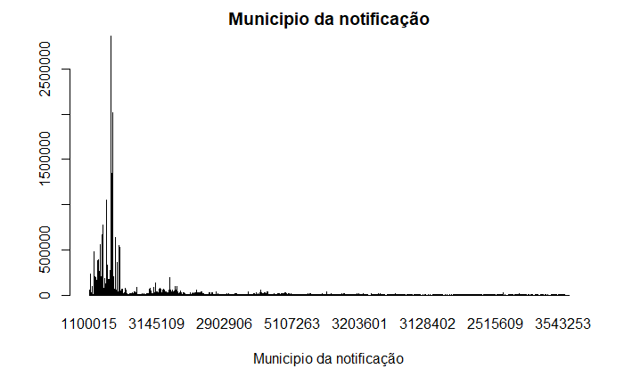

```r
counts = table(dados$municipioNotificacaoIBGE)
barplot(counts, main = "Municipio da notificação",
        xlab = "Municipio da notificação")
```

# 5 Explorando dados temporais

Antes de explorar os dados temporais. Os dados são convertidos para Date:

```r
dados = transform(dados,
                  dataInicioSintomas = as.Date(dataInicioSintomas, "%Y-%m-%d"),
                  dataNotificacao = as.Date(dataNotificacao, "%Y-%m-%d"),
                  dataTeste = as.Date(dataTeste, "%Y-%m-%d"),
                  dataEncerramento = as.Date(dataEncerramento, "%Y-%m-%d"))
```

## 5.1 Data do início dos síntomas

```r
summary(dados$dataInicioSintomas)
```

```
        Min.      1st Qu.       Median         Mean      3rd Qu.         Max.         NA's
"1899-11-28" "2020-07-24" "2020-10-22" "2020-10-13" "2021-01-04" "9090-11-05"    "1054482"
```

## 5.2 Data da notificação

```r
summary(dados$dataNotificacao)
```

```
        Min.      1st Qu.       Median         Mean      3rd Qu.         Max.         NA's
"1970-01-01" "2020-08-01" "2020-10-25" "2020-10-20" "2021-01-09" "2080-07-23"      "23786"
```

## 5.3 Data do teste

```r
summary(dados$dataTeste)
```

```
        Min.      1st Qu.       Median         Mean      3rd Qu.         Max.         NA's
"0200-10-30" "2020-07-31" "2020-10-20" "2020-10-16" "2021-01-04" "2202-10-19"    "8086031"
```

## 5.4 Data de encerramento

```r
summary(dados$dataEncerramento)
```

```
        Min.      1st Qu.       Median         Mean      3rd Qu.         Max.         NA's
"0202-09-01" "2020-08-18" "2020-10-29" "2020-10-29" "2021-01-19" "2021-03-31"   "26766763"
```

# 6 Valores faltantes - NAs

```r
dim(dados[!complete.cases(dados),])[1]
```

```
[1] 29130968
```

# 7 Tratamento e limpeza dos dados

A moda

```r
getMode <- function(v) {
   uniqv <- unique(v)
   uniqv[which.max(tabulate(match(v, uniqv)))]
}
```

## 7.1 Profissional de saúde

Campo obrigatório. A dimensão tem o problema de ter dados fora de domínio, falta de padronização e nulos. Pela documentação só são aceitos:

- Sim
- Não

```r
unique(dados$profissionalSaude)
```

```
[1] Não       Sim       null      <NA>      undefined Nao       Médico
Levels: Não null Sim undefined Médico Nao
```

```r
dados[grepl("Médico", dados$profissionalSaude,
            fixed = TRUE),]$profissionalSaude = "Sim"
dados[grepl("Nao", dados$profissionalSaude,
            fixed = TRUE),]$profissionalSaude = "Não"

myMode = getMode(dados$profissionalSaude)

cond_x = dados$profissionalSaude %in% c("undefined", "null")
dados[cond_x,]$profissionalSaude = myMode

dados[is.na(dados$profissionalSaude),]$profissionalSaude = myMode

summary(dados$profissionalSaude)
```

```
      Não      null       Sim undefined    Médico       Nao
 40647678         0   2262978         0         0         0
```

```r
dados$profissionalSaude = factor(dados$profissionalSaude)
levels(dados$profissionalSaude) = c("Nao", "Sim")
summary(dados$profissionalSaude)
```

```
     Nao      Sim
40647678  2262978
```

## 7.2 Idade

Campo obrigatório. A dimensão tem muitos dados fora do domínio e também tem nulos.

Transformando os dados a inteiros.

```r
dados = transform(dados, idade = as.integer(idade))
```

[output not shown]

Vendo o conteúdo dos dados

```r
summary(dados$idade)
```

```
   Min. 1st Qu.  Median    Mean 3rd Qu.    Max.    NA's
   0.00   26.00   37.00   38.64   50.00 7175.00   10556
```

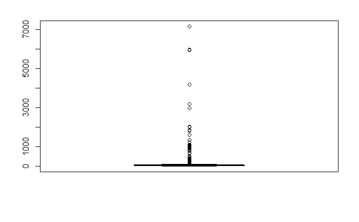

```r
boxplot(dados$idade)
```

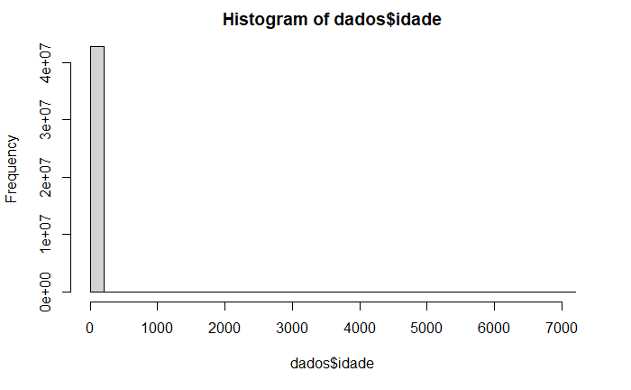

```r
hist(dados$idade)
```

Segundo o Gerontology Research Group (GRG) a idade do brasileiro mais velhor vivo é de 116 anos ([GRG News announces new Brazil oldest person record](https://grg.org/GRGNews2020.html)).

```r
myMedian = median(dados[dados$idade >= 0 & dados$idade <= 116,]$idade, na.rm = T)
dados[is.na(dados$idade) | dados$idade < 0 | dados$idade > 116,]$idade = myMedian

summary(dados$idade)
```

```
   Min. 1st Qu.  Median    Mean 3rd Qu.    Max.
   0.00   26.00   37.00   38.58   50.00  116.00
```

## 7.3 Sexo

Campo obrigatório. A dimensão tem o problema de ter dados fora de domínio e nulos. Pela documentação só são aceitos:

- Feminino
- Masculino

```r
unique(dados$sexo)
```

```
[1] Masculino  Feminino   null       Indefinido undefined  M
Levels: Feminino Indefinido Masculino null undefined M
```

```r
dados[dados$sexo == "M",]$sexo = "Masculino"

myMode = getMode(dados$sexo)
dados[dados$sexo %in% c("Indefinido", "null", "undefined"),]$sexo = myMode

summary(dados$sexo)
```

```
  Feminino Indefinido  Masculino       null  undefined          M
  22227479          0   20683177          0          0          0
```

```r
dados$sexo = factor(dados$sexo)
summary(dados$sexo)
```

```
 Feminino Masculino
 22227479  20683177
```

## 7.4 Estado do teste

A dimensão tem o problema de ter dados nulos. Pela documentação só são aceitos:

- Solicitado
- Coletado
- Concluído
- Exame Não Solicitado

Foi adicionado o nivel **Indefinido** para os dados nulos.

```r
unique(dados$estadoTeste)
```

```
[1] Coletado             Concluído            Solicitado           null
[5] Exame Não Solicitado <NA>                 undefined
Levels: Coletado Concluído Exame Não Solicitado null Solicitado undefined
```

```r
levels(dados$estadoTeste) = c(levels(dados$estadoTeste), "Indefinido")

cond_x = is.na(dados$estadoTeste) | dados$estadoTeste %in% c("null","undefined")
dados[cond_x,]$estadoTeste = "Indefinido"

summary(dados$estadoTeste)
```

```
            Coletado            Concluído Exame Não Solicitado                 null
             3963201             31756805              2412794                    0
          Solicitado            undefined           Indefinido
             2971316                    0              1806540
```

```r
dados$estadoTeste = factor(dados$estadoTeste)
levels(dados$estadoTeste) = c("Coletado", "Concluido","Exame Nao Solicitado",
                              "Solicitado", "Indefinido")
summary(dados$estadoTeste)
```

```
            Coletado            Concluido Exame Nao Solicitado           Solicitado
             3963201             31756805              2412794              2971316
          Indefinido
             1806540
```

## 7.5 Tipo de teste

A dimensão tem o problema de ter dados com falta de padronização e nulos. Pela documentação só são aceitos:

- RT-PCR
- TESTE RÁPIDO - ANTICORPO
- TESTE RÁPIDO - ANTÍGENO
- Enzimaimunoensaio - ELISA IgM
- Imunoensaio por Eletroquimioluminescência - ECLIA IgG
- Quimioluminescência - CLIA.

Foi adicionado o nivel **Indefinido** para os dados nulos.

```r
unique(dados$tipoTeste)
```

```
 [1] null
 [2] RT-PCR
 [3] TESTE RÁPIDO - ANTICORPO
 [4] TESTE RÁPIDO - ANTÍGENO
 [5] Imunoensaio por Eletroquimioluminescência - ECLIA IgG
 [6] Enzimaimunoensaio - ELISA IgM
 [7] Imunoensaio por Eletroquimioluminescência \023 ECLIA
 [8] Quimioluminescência - CLIA
 [9] Enzimaimunoensaio \023 ELISA
[10] Teste rápido
[11] <NA>
[12] undefined
11 Levels: Enzimaimunoensaio \023 ELISA ... undefined
```

```r
levels(dados$tipoTeste) = c(levels(dados$tipoTeste), "Indefinido")
dados[is.na(dados$tipoTeste),]$tipoTeste = "Indefinido"
dados[dados$tipoTeste == "null",]$tipoTeste = "Indefinido"
dados[dados$tipoTeste == "undefined",]$tipoTeste = "Indefinido"

cond_x = dados$tipoTeste == "Enzimaimunoensaio \023 ELISA"
dados[cond_x,]$tipoTeste = "Enzimaimunoensaio - ELISA IgM"

cond_x = dados$tipoTeste == "Imunoensaio por Eletroquimioluminescência \023 ECLIA"
dados[cond_x,]$tipoTeste = "Imunoensaio por Eletroquimioluminescência - ECLIA IgG"

cond_x = dados$tipoTeste == "Teste rápido"
dados[cond_x,]$tipoTeste = "TESTE RÁPIDO - ANTICORPO"

summary(dados$tipoTeste)
```

```
                         Enzimaimunoensaio \023 ELISA
                                                    0
                        Enzimaimunoensaio - ELISA IgM
                                                60060
 Imunoensaio por Eletroquimioluminescência \023 ECLIA
                                                    0
Imunoensaio por Eletroquimioluminescência - ECLIA IgG
                                                81141
                                                 null
                                                    0
                           Quimioluminescência - CLIA
                                                27260
                                               RT-PCR
                                             15652759
                             TESTE RÁPIDO - ANTICORPO
                                             15703602
                              TESTE RÁPIDO - ANTÍGENO
                                              4063395
                                         Teste rápido
                                                    0
                                            undefined
                                                    0
                                           Indefinido
                                              7322439
```

```r
dados$tipoTeste = factor(dados$tipoTeste)
levels(dados$tipoTeste) = c("ELISA IgM", "ECLIA IgG", "CLIA", "RT-PCR",
                            "ANTICORPO", "ANTIGENO", "Indefinido")
summary(dados$tipoTeste)
```

```
 ELISA IgM  ECLIA IgG       CLIA     RT-PCR  ANTICORPO   ANTIGENO Indefinido
     60060      81141      27260   15652759   15703602    4063395    7322439
```

## 7.6 Resultado do teste

A dimensão tem o problema de ter dados nulos. Pela documentação só são aceitos:

- Negativo
- Positivo
- Inconclusivo ou Indeterminado

Foi adicionado o nivel **Indefinido** para os dados nulos.

```r
unique(dados$resultadoTeste)
```

```
[1] null                          Positivo                      Negativo
[4] Inconclusivo ou Indeterminado <NA>                          undefined
Levels: Inconclusivo ou Indeterminado Negativo null Positivo undefined
```

```r
levels(dados$resultadoTeste) = c(levels(dados$resultadoTeste), "Indefinido")
dados[is.na(dados$resultadoTeste),]$resultadoTeste = "Indefinido"
dados[dados$resultadoTeste  == "undefined",]$resultadoTeste = "Indefinido"
dados[dados$resultadoTeste == "null",]$resultadoTeste = "Indefinido"

summary(dados$resultadoTeste)
```

```
Inconclusivo ou Indeterminado                      Negativo                          null
                        58470                      19889219                             0
                     Positivo                     undefined                    Indefinido
                     10976219                             0                      11986748
```

```r
dados$resultadoTeste = factor(dados$resultadoTeste)
summary(dados$resultadoTeste)
```

```
Inconclusivo ou Indeterminado                      Negativo                      Positivo
                        58470                      19889219                      10976219
                   Indefinido
                     11986748
```

## 7.7 Evolução do caso

A dimensão tem o problema de ter NAs. Pela documentação só são aceitos:

- Cancelado
- Ignorado
- Em tratamento domiciliar
- Internado em UTI
- Internado
- Óbito
- Cura

Foi adicionado o nivel **Indefinido** para os dados nulos.

```r
unique(dados$evolucaoCaso)
```

```
[1] <NA>                     Cura                     Cancelado
[4] Em tratamento domiciliar Internado                Óbito
[7] Ignorado                 Internado em UTI
7 Levels: Cancelado Cura Em tratamento domiciliar Ignorado Internado ... Óbito
```

```r
levels(dados$evolucaoCaso) = c(levels(dados$evolucaoCaso), "Indefinido")
dados[is.na(dados$evolucaoCaso),]$evolucaoCaso = "Indefinido"

summary(dados$evolucaoCaso)
```

```
               Cancelado                     Cura Em tratamento domiciliar
                 2112396                 12090024                  1155882
                Ignorado                Internado         Internado em UTI
                 2115777                    22620                     4639
                   Óbito               Indefinido
                   71169                 25338149
```

```r
dados$evolucaoCaso = factor(dados$evolucaoCaso)
levels(dados$evolucaoCaso)[7] = "Obito"
summary(dados$evolucaoCaso)
```

```
               Cancelado                     Cura Em tratamento domiciliar
                 2112396                 12090024                  1155882
                Ignorado                Internado         Internado em UTI
                 2115777                    22620                     4639
                   Obito               Indefinido
                   71169                 25338149
```

## 7.8 Classificação final

Transformando os dados a factores.

```r
dados = transform(dados, classificacaoFinal = as.factor(classificacaoFinal))
```

A dimensão tem o problema de ter dados com falta de padronização e nulos. Pela documentação só são aceitos:

- Descartado
- Confirmado Clínico-Imagem
- Confirmado Clínico-Epidemiológico
- Confirmado por Critério Clínico
- Confirmado Laboratorial
- Síndrome Gripal Não Especificada

Foi adicionado o nivel **Indefinido** para os dados nulos.

```r
unique(dados$classificacaoFinal)
```

```
 [1] <NA>                               Confirmado Laboratorial
 [3] Descartado                         Confirmado Clínico-Epidemiológico
 [5] Confirmação Laboratorial           Síndrome Gripal Não Especificada
 [7] Confirmado Clínico-Imagem          Confirmado por Critério Clínico
 [9] Confirmação Clínico Epidemiológico Sindrome Gripal Nao Especificada
[11] Confirmado Clinico-Epidemiologico  Confirmado Clinico-Imagem
11 Levels: Confirmação Clínico Epidemiológico ... Síndrome Gripal Não Especificada
```

```r
levels(dados$classificacaoFinal) = c(levels(dados$classificacaoFinal),
                                     "Indefinido")
dados[is.na(dados$classificacaoFinal),]$classificacaoFinal = "Indefinido"

cond_x = dados$classificacaoFinal == "Confirmado Clinico-Epidemiologico"
dados[cond_x,]$classificacaoFinal = "Confirmado Clínico-Epidemiológico"

cond_x = dados$classificacaoFinal == "Confirmação Clínico Epidemiológico"
dados[cond_x,]$classificacaoFinal = "Confirmado Clínico-Epidemiológico"

cond_x = dados$classificacaoFinal == "Confirmação Laboratorial"
dados[cond_x,]$classificacaoFinal = "Confirmado Laboratorial"

cond_x = dados$classificacaoFinal == "Sindrome Gripal Nao Especificada"
dados[cond_x,]$classificacaoFinal = "Síndrome Gripal Não Especificada"

cond_x = dados$classificacaoFinal == "Confirmado Clinico-Imagem"
dados[cond_x,]$classificacaoFinal = "Confirmado Clínico-Imagem"

summary(dados$classificacaoFinal)
```

```
Confirmação Clínico Epidemiológico           Confirmação Laboratorial
                                 0                                  0
 Confirmado Clinico-Epidemiologico  Confirmado Clínico-Epidemiológico
                                 0                             283006
         Confirmado Clinico-Imagem          Confirmado Clínico-Imagem
                                 0                              10031
           Confirmado Laboratorial    Confirmado por Critério Clínico
                           7976514                             136385
                        Descartado   Sindrome Gripal Nao Especificada
                           8841150                                  0
  Síndrome Gripal Não Especificada                         Indefinido
                           1884354                           23779216
```

```r
dados$classificacaoFinal = factor(dados$classificacaoFinal)
levels(dados$classificacaoFinal) = c("Cli.-Epid.", "Cli.-Img.", "Lab.",
                                     "Cri. Cli.", "Desc.", "SGNE", "Indefinido")
summary(dados$classificacaoFinal)
```

```
Cli.-Epid.  Cli.-Img.       Lab.  Cri. Cli.      Desc.       SGNE Indefinido
    283006      10031    7976514     136385    8841150    1884354   23779216
```

## 7.9 Estado de residência

Campo obrigatório. A dimensão tem problemas de nulos.

```r
detect = str_detect(levels(dados$estadoIBGE), regex("[0-9][0-9]"))
indi = which(!detect)
levels(dados$estadoIBGE)[indi]
```

```
[1] "null"      "undefined"
```

```r
levels(dados$estadoIBGE)[indi] = "Indefinido"

summary(dados$estadoIBGE)
```

```
        12         27         13 Indefinido         16         29         23         53
    217398     522015     895946       1665     175690    2595572    1488706     544786
        32         52         21         31         50         51         15         25
    511815    1607311     791804    4148110     835233     559992     880382     972974
        26         22         11         14         17         24         28         33
   1353020     591774     584247     240192     338515     913972     359794    2829491
        35         41         42         43
  10934165     125303    4001682    3889102
```

## 7.10 Municipio de residência

Campo obrigatório. A dimensão tem problemas de nulos.

```r
detect = str_detect(levels(dados$municipioIBGE),
                    regex("[0-9][0-9][0-9][0-9][0-9][0-9][0-9]"))
indi = which(!detect)
levels(dados$municipioIBGE)[indi]
```

```
[1] "null"      "undefined"
```

```r
levels(dados$municipioIBGE)[indi] = "Indefinido"

summary(dados$municipioIBGE)
```

```
 3550308  4205407  3304557  3106200  2927408  5300108  1302603  5208707  4314902  2304400
 2907417  1852357  1034755   689967   647340   543937   530271   518872   484891   416416
 2611606  3548708  5002704  3509502  3170206  2408102  3549805  2507507  4209102  5201405
  405509   351950   350690   340563   336649   301643   284831   256292   247312   236284
 3304904  1100205  3549904  2704302  1400100  4305108  3552205  3547809  3543402  3303302
  230373   223072   215200   197046   196844   190548   190388   185069   170639   169198
 2211001  3518800  3525904  1501402  2111300  2800308  3538709  3118601  4304606  4216602
  166654   163812   162258   160797   157740   152827   152100   148160   134443   133937
 3534401  3530607  3529401  4202404  3300456  3506003  4314407  4204202  3548500  4314100
  127326   127146   123418   123053   120997   118731   111395   108354   107589   105988
 3505708  1200401  3513801  3552809  3106705  2933307  1600303  4208203  2504009  4316907
  103972   102730   100130    95895    94382    92450    91992    91726    91537    90894
 5003702  2910800  3502804  4315602  3503208  4313409  2403251  3143302  3507506  2700300
   89277    88438    88315    88179    86294    86010    85330    84158    83491    82890
 3170107  2914802  3516200  4309209  3131307  2905701  3554102  3541406  2408003  2607901
   82057    80418    79255    78796    78544    76418    73811    73699    72757    72740
 3510500  4318705  2604106  4204608  3306305  3301009  3205002  1506807  2307304  3302700
   72485    71828    71326    70522    70376    70097    69192    68901    67919    67018
 4211900  3524402  3205309  3205200  3505500  3529005  1702109  3526902  3543907  (Other)
   66969    66531    66302    66260    65889    65447    65272    64358    64153 21620178
```

## 7.11 Estado da notificação

Campo gerado pelo sistema. A dimensão tem problemas de nulos.

```r
detect = str_detect(levels(dados$estadoNotificacaoIBGE), regex("[0-9][0-9]"))
indi = which(!detect)
levels(dados$estadoNotificacaoIBGE)[indi]
```

```
[1] "null"
```

```r
levels(dados$estadoNotificacaoIBGE)[indi] = "Indefinido"

cond_x = is.na(dados$estadoNotificacaoIBGE)
dados[cond_x,]$estadoNotificacaoIBGE = "Indefinido"

summary(dados$estadoNotificacaoIBGE)
```

```
        11         12         13         14         15         16         17         21
    581725     211196     840131     233765     865175     166219     336989     758110
        22         23         24         25         26         27         28         29
    583225    1405010     902491     959003    1338107     510525     356537    2532947
        31         32         33         35         41         42         43         50
   3817452     472077    2789846    9113102    1346398    4029429    3871653     838613
        51         52         53 Indefinido
    545186    1539564     527881    1438300
```

## 7.12 Municipio da notificação

Campo gerado pelo sistema. A dimensão tem problemas de nulos.

```r
detect = str_detect(levels(dados$municipioNotificacaoIBGE), regex("[0-9][0-9][0-9][0-9][0-9][0-9][0-9]"))
indi = which(!detect)
levels(dados$municipioNotificacaoIBGE)[indi]
```

```
[1] "null"
```

```r
levels(dados$municipioNotificacaoIBGE)[indi] = "Indefinido"

cond_x = is.na(dados$municipioNotificacaoIBGE)
dados[cond_x,]$municipioNotificacaoIBGE = "Indefinido"

summary(dados$municipioNotificacaoIBGE)
```

```
   3550308    4205407 Indefinido    4106902    3304557    3106200    2927408    4314902
   2863639    2012970    1463219    1343812    1052356     775374     667381     633933
   2611606    5208707    5300108    1302603    2408102    2304400    5002704    3509502
    561144     552604     525182     479338     390101     380856     356545     327522
   4209102    3549805    2507507    1100205    5201405    3549904    3303302    4305108
    286501     269852     264387     228332     217677     215483     213912     207718
   2704302    1400100    3548708    1501402    3304904    3170206    2800308    3525904
    203483     199117     196428     192402     187730     184901     182339     174043
   2211001    2111300    3547809    4202404    3118601    3552205    3300456    4304606
    166950     158733     148973     139813     137579     132286     128531     127765
   3543402    3538709    4314100    4204202    4314407    3505708    3548500    3131307
    121471     117437     114266     112264     111675     108296     107746     106573
   3530607    3506003    3518800    4208203    4313409    1200401    2504009    3534401
    105471     105282     100239     100053      99340      99211      94456      94353
   4316907    5003702    3106705    2933307    2700300    1600303    4315602    3306305
     94155      90945      90085      88304      87501      86921      84389      82588
   2910800    3143302    3205309    2914802    4204608    3301009    3548807    2408003
     82195      79376      78447      78122      77551      76702      75337      74730
   2307304    3501608    1506807    1702109    2604106    3170107    3302403    3502804
     72449      71938      70682      70417      70266      70057      69739      69665
   4202008    2905701    2105302    3548906    5201108    3510500    3300100    4311403
     66096      63622      63136      63088      63023      62834      62827      62323
   3503208    3513009    3302700    5220454    4307005    4209300    3136702    3516200
     62227      61836      61504      60018      59972      59579      59563      59534
   3205002    4318705    3205200    (Other)
     59211      58570      57681   19202407
```

## 7.13 Id

```r
dados[duplicated(dados$Id),]
```

| id | dataNotificacao | dataInicioSintomas | sintomas | profissionalSaude | condicoes | estadoTeste | dataTeste | tipoTeste | resultadoTeste | sexo | estadoIBGE | municipioIBGE | estadoNotificacaoIBGE | municipioNotificacaoIBGE | idade | dataEncerramento | evolucaoCaso | classificacaoFinal |
| --- | --- | --- | --- | --- | --- | --- | --- | --- | --- | --- | --- | --- | --- | --- | --- | --- | --- | --- |

## 7.14 Data do início dos síntomas

Data quando os dados foram pegos.

```r
dateDownload = "2021-04-01"
```

Campo obrigatório. A dimensão está fora do domínio. O paciente zero viajou para a Itália entre o 9 e 21 de fevereiro do 2020. Então a data do início dos síntomas mínima possível seria o 9 de fevereiro ([Primeiro caso confirmado de Covid-19 no Brasil ocorreu em SP e completa seis meses nesta quarta](https://g1.globo.com/sp/sao-paulo/noticia/2020/08/26/primeiro-caso-confirmado-de-covid-19-no-brasil-ocorreu-em-sp-e-completa-seis-meses-nesta-quarta.ghtml)). E a máxima data seria a data atual.

```r
cond_x = dados$dataInicioSintomas >= "2020-02-09"
cond_x2 = cond_x & dados$dataInicioSintomas <= dateDownload
correctInterval = cond_x2 & !is.na(dados$dataInicioSintomas)

median_dataInicioSintomas = median(dados[correctInterval,]$dataInicioSintomas)

dados[!correctInterval,]$dataInicioSintomas = median_dataInicioSintomas

summary(dados$dataInicioSintomas)
```

```
        Min.      1st Qu.       Median         Mean      3rd Qu.         Max.
"2020-02-09" "2020-07-26" "2020-10-22" "2020-10-14" "2021-01-02" "2021-04-01"
```

## 7.15 Data da notificação

Campo obrigatório. A dimensão está fora do domínio. O paciente zero viajou para a Itália entre o 9 e 21 de fevereiro do 2020. Então a data da notificação mínima possível seria quando ele voltou ao Brasil o 21 de fevereiro ([Primeiro caso confirmado de Covid-19 no Brasil ocorreu em SP e completa seis meses nesta quarta](https://g1.globo.com/sp/sao-paulo/noticia/2020/08/26/primeiro-caso-confirmado-de-covid-19-no-brasil-ocorreu-em-sp-e-completa-seis-meses-nesta-quarta.ghtml)). E a máxima data seria a data atual.

```r
cond_x = dados$dataNotificacao >= "2020-02-21"
cond_x2 = cond_x & dados$dataNotificacao <= dateDownload
correctInterval = cond_x2 & !is.na(dados$dataNotificacao)

median_dataNotificacao = median(dados[correctInterval,]$dataNotificacao)

dados[!correctInterval,]$dataNotificacao = median_dataNotificacao

summary(dados$dataNotificacao)
```

```
        Min.      1st Qu.       Median         Mean      3rd Qu.         Max.
"2020-02-21" "2020-08-01" "2020-10-25" "2020-10-20" "2021-01-09" "2021-04-01"
```

## 7.16 Data do teste

A dimensão está fora do domínio. O paciente zero viajou para a Itália entre o 9 e 21 de fevereiro do 2020. Então a data do teste mínima possível seria quando ele voltou ao Brasil o 21 de fevereiro ([Primeiro caso confirmado de Covid-19 no Brasil ocorreu em SP e completa seis meses nesta quarta](https://g1.globo.com/sp/sao-paulo/noticia/2020/08/26/primeiro-caso-confirmado-de-covid-19-no-brasil-ocorreu-em-sp-e-completa-seis-meses-nesta-quarta.ghtml)). E a máxima data seria a data atual.

```r
cond_x = dados$dataTeste >= "2020-02-21"
cond_x2 = cond_x & dados$dataTeste <= dateDownload
correctInterval = cond_x2 & !is.na(dados$dataTeste)

dados[!correctInterval,]$dataTeste = "2020-01-01"

summary(dados$dataTeste)
```

```
        Min.      1st Qu.       Median         Mean      3rd Qu.         Max.
"2020-01-01" "2020-06-09" "2020-09-08" "2020-08-23" "2020-12-16" "2021-03-31"
```

## 7.17 Data de encerramento

A dimensão está fora do domínio. O paciente zero viajou para a Itália entre o 9 e 21 de fevereiro do 2020. Então a data de encerramento mínima possível seria quando ele voltou ao Brasil o 21 de fevereiro ([Primeiro caso confirmado de Covid-19 no Brasil ocorreu em SP e completa seis meses nesta quarta](https://g1.globo.com/sp/sao-paulo/noticia/2020/08/26/primeiro-caso-confirmado-de-covid-19-no-brasil-ocorreu-em-sp-e-completa-seis-meses-nesta-quarta.ghtml)). E a máxima data seria a data atual.

```r
cond_x = dados$dataEncerramento >= "2020-02-21"
cond_x2 = cond_x & dados$dataEncerramento <= dateDownload
correctInterval = cond_x2 & !is.na(dados$dataEncerramento)

dados[!correctInterval,]$dataEncerramento = "2020-01-01"

summary(dados$dataEncerramento)
```

```
        Min.      1st Qu.       Median         Mean      3rd Qu.         Max.
"2020-01-01" "2020-01-01" "2020-01-01" "2020-04-24" "2020-09-08" "2021-03-31"
```

# 8 Últimas modificações

Deletando a coluna dos IDs

```r
dados$id = NULL
```

# 9 Resultado final dos dados

Mostrando os dados já tratados, menos síntomas nem condições

```r
head(dados)
```

|  | dataNotificacao | dataInicioSintomas | sintomas | profissionalSaude | condicoes | estadoTeste | dataTeste | tipoTeste | resultadoTeste | sexo | estadoIBGE | municipioIBGE | estadoNotificacaoIBGE | municipioNotificacaoIBGE | idade | dataEncerramento | evolucaoCaso | classificacaoFinal |
| --- | --- | --- | --- | --- | --- | --- | --- | --- | --- | --- | --- | --- | --- | --- | --- | --- | --- | --- |
| 1 | 2020-04-20 | 2020-04-15 | Dor de Garganta, Tosse | Nao | null | Coletado | 2020-04-20 | Indefinido | Indefinido | Masculino | 12 | 1200450 | 12 | 1200401 | 51 | 2020-01-01 | Indefinido | Indefinido |
| 2 | 2020-04-21 | 2020-04-13 | Outros | Nao | null | Coletado | 2020-04-21 | Indefinido | Indefinido | Feminino | 12 | 1200450 | 12 | 1200401 | 47 | 2020-01-01 | Indefinido | Indefinido |
| 3 | 2020-04-22 | 2020-04-12 | Febre, Tosse, Outros | Nao | Doenças cardíacas crônicas, Diabetes | Coletado | 2020-04-22 | Indefinido | Indefinido | Feminino | 12 | 1200401 | 12 | 1200401 | 57 | 2020-01-01 | Indefinido | Indefinido |
| 4 | 2020-03-18 | 2020-03-17 | Febre, Tosse, Outros | Nao | null | Concluido | 2020-03-18 | RT-PCR | Positivo | Feminino | 12 | 1200401 | 12 | 1200401 | 27 | 2020-04-10 | Cura | Lab. |
| 5 | 2020-03-18 | 2020-03-18 | Tosse, Febre, Dor de Garganta, Dispneia, Outros | Sim | null | Concluido | 2020-03-19 | RT-PCR | Positivo | Masculino | 12 | 1200401 | 12 | 1200401 | 30 | 2020-04-10 | Cura | Lab. |
| 6 | 2020-03-24 | 2020-03-17 | Febre | Nao | null | Concluido | 2020-03-24 | RT-PCR | Positivo | Masculino | 12 | 1200401 | 12 | 1200401 | 34 | 2020-04-13 | Cura | Lab. |

```r
summary(dados)
```

```
 dataNotificacao      dataInicioSintomas     sintomas         profissionalSaude
 Min.   :2020-02-21   Min.   :2020-02-09   Length:42910656    Nao:40647678
 1st Qu.:2020-08-01   1st Qu.:2020-07-26   Class :character   Sim: 2262978
 Median :2020-10-25   Median :2020-10-22   Mode  :character
 Mean   :2020-10-20   Mean   :2020-10-14
 3rd Qu.:2021-01-09   3rd Qu.:2021-01-02
 Max.   :2021-04-01   Max.   :2021-04-01

  condicoes                       estadoTeste         dataTeste               tipoTeste
 Length:42910656    Coletado            : 3963201   Min.   :2020-01-01   ELISA IgM :   60060
 Class :character   Concluido           :31756805   1st Qu.:2020-06-09   ECLIA IgG :   81141
 Mode  :character   Exame Nao Solicitado: 2412794   Median :2020-09-08   CLIA      :   27260
                    Solicitado          : 2971316   Mean   :2020-08-23   RT-PCR    :15652759
                    Indefinido          : 1806540   3rd Qu.:2020-12-16   ANTICORPO :15703602
                                                    Max.   :2021-03-31   ANTIGENO  : 4063395
                                                                         Indefinido: 7322439
                       resultadoTeste            sexo            estadoIBGE
 Inconclusivo ou Indeterminado:   58470   Feminino :22227479   35     :10934165
 Negativo                     :19889219   Masculino:20683177   31     : 4148110
 Positivo                     :10976219                        42     : 4001682
 Indefinido                   :11986748                        43     : 3889102
                                                               33     : 2829491
                                                               29     : 2595572
                                                               (Other):14512534
 municipioIBGE      estadoNotificacaoIBGE municipioNotificacaoIBGE     idade
 3550308: 2907417   35     : 9113102      3550308   : 2863639      Min.   :  0.00
 4205407: 1852357   42     : 4029429      4205407   : 2012970      1st Qu.: 26.00
 3304557: 1034755   43     : 3871653      Indefinido: 1463219      Median : 37.00
 3106200:  689967   31     : 3817452      4106902   : 1343812      Mean   : 38.58
 2927408:  647340   33     : 2789846      3304557   : 1052356      3rd Qu.: 50.00
 5300108:  543937   29     : 2532947      3106200   :  775374      Max.   :116.00
 (Other):35234883   (Other):16756227      (Other)   :33399286
 dataEncerramento                       evolucaoCaso       classificacaoFinal
 Min.   :2020-01-01   Indefinido              :25338149   Cli.-Epid.:  283006
 1st Qu.:2020-01-01   Cura                    :12090024   Cli.-Img. :   10031
 Median :2020-01-01   Ignorado                : 2115777   Lab.      : 7976514
 Mean   :2020-04-24   Cancelado               : 2112396   Cri. Cli. :  136385
 3rd Qu.:2020-09-08   Em tratamento domiciliar: 1155882   Desc.     : 8841150
 Max.   :2021-03-31   Obito                   :   71169   SGNE      : 1884354
                      (Other)                 :   27259   Indefinido:23779216
```

# 10 Salvando objeto dos dados

Os dados são salvos num objeto do R

```r
save(dados, file = "output/qdscovid_registers.Rda")
```